# TD Parcours **Data Science** - Machine learning

Groupe 1 - AVIT // Chloé on sait pas comment encore // SOW

December 10, 2020

Dans ce travail pratique destiné à nous familiariser aux méthodes de Machine Learning, nous allons présenter une technique qui a connu un gros essort depuis sa mise en place pour des problématiques de regression comme en classification.

# 1 Importation des données

Nous commençons par importer la librairie **caret** qui contient à la fois le jeu de donnée **BloodBrain** sur laquelle nous allons baser notre template de machine learning ainsi que les différentes fonctions et méthodes utiles. Nous importons de plus la librairie tidyverse est une collection de plusieurs librairies dont readr, dplyr, tidyr, ggplot2 pour un pouvoir traiter et visualiser avec la philosophie “tidy” notre jeu de donnée.

```r
library(caret)
library(tidyverse)
```

L’importation du jeu de données BloodBrain à partir de caret se fait facilement avec la fonction utils::data().

```r
data(BloodBrain)
```

**BloodBrain** contient un dataframe **bbbDescr** de 208 observations et 134 variables, ainsi qu’un vecteur réponse **logBBB** de taille 208. Il est issu des travaux de Mente et Lombardo des laboratoires de R&D du géant américain Pfizer. Ces dernières dans leur [article](https://link.springer.com/article/10.1007/s10822-005-9001-7) paru en 2005 dans le Journal of Computer-Aided Molecular Design ont développé des modèles qui prédisent le log ratio de la concentration de composés chimiques dans le cerveau et dans sa concentration dans le sang.  
On étudie donc ici le rôle de l’interface sang/encéphale, d’où le nom du jeu de données : Blood Brain Barrier. Pour chaque composé chimique sont calculés 3 ensembles de descripteurs molécualires : **MOE 2D**, **rule-of-five** et **Charge Polar Surface Area**. Le dataframe bbbDescr est donc constitué par les variables explicatives X (il s’agit des features) eet le vecteur réponse logBBB eest notre variable expliquée (notre target). Nous sommes donc dans le cadre d’un apprentissage supervisé.

Afin de mieux appréhender cette problématique et avant toute étape de modélisation, nous étudierons nos features et target. Nous avons décidé par souci de praticité de lier le vecteur réponse à notre dataframe de variables explicatives. La majorité des jeu de données pour le machine leaning adoptant à priori cette configuration.

```r
mydata <- cbind(bbbDescr, data.frame(logBBB))
```

**Étude des variables explicatives : Features** Nous pouvons tout d’abord regarder la structure du jeu de données.

```r
str(mydata[,-135]) # -135 pour ne pas considérer la colonne target (logBBB)
```

```
## 'data.frame':    208 obs. of  134 variables:
##  $ tpsa                : num  12 49.3 50.5 37.4 37.4 ...
##  $ nbasic              : int  1 0 1 0 1 1 1 1 1 1 ...
##  $ negative            : int  0 0 0 0 0 0 0 0 0 0 ...
##  $ vsa_hyd             : num  167.1 92.6 295.2 319.1 299.7 ...
##  $ a_aro               : int  0 6 15 15 12 11 6 12 12 6 ...
##  $ weight              : num  156 151 366 383 326 ...
##  $ peoe_vsa.0          : num  76.9 38.2 58.1 62.2 74.8 ...
##  $ peoe_vsa.1          : num  43.4 25.5 124.7 124.7 118 ...
##  $ peoe_vsa.2          : num  0 0 21.7 13.2 33 ...
##  $ peoe_vsa.3          : num  0 8.62 8.62 21.79 0 ...
##  $ peoe_vsa.4          : num  0 23.3 17.4 0 0 ...
##  $ peoe_vsa.5          : num  0 0 0 0 0 0 0 0 0 0 ...
##  $ peoe_vsa.6          : num  17.24 0 8.62 8.62 8.62 ...
##  $ peoe_vsa.0.1        : num  18.7 49 83.8 83.8 83.8 ...
```

[output cut: 86 more lines]

L’ensemble des variables sont de type continues (integer/numeric).

Nous cherchons aussi la présence de valeurs manquantes qui peuvent alterér les performances de prédiction de nos modèles.

```r
table(is.na(mydata[,-135]))
```

```
##
## FALSE
## 27872
```

Nous constatons l’absence de données manquantes.

Nous pouvons aussi sur nos features étudier les potentielles corrélations entre variables. L’étude des corrélations entre variables explicatives est très important dans une démarche de modélisation et de prédiction. Si une multitude de variables sont corrélées cela induit une redondance dans l’information. Ce qui est rarement souhaitable. Nous utilisons ici la fonction corrplot du package du même nom.

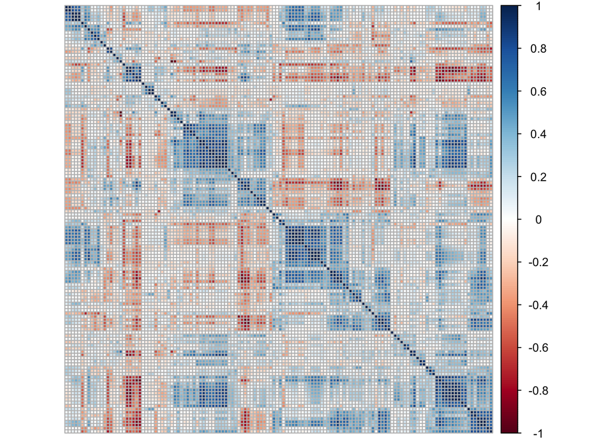

Le heatmap ci-dessus révéle la présence d’une multitude de corrélations (positives et négatives) dans nos variables explicatives. Certains auteurs recommendent d’éliminer les variables beaucoup trop corrélées. Nous décidons nous de poursuivre avec l’ensemble de nos features.

**Étude de la variable réponse : Target**

Nous pouvons d’abord sortir les première statistiques qui lui sont associées.

```r
summary(mydata$logBBB)
```

```
##     Min.  1st Qu.   Median     Mean  3rd Qu.     Max.
## -2.15000 -0.42250  0.02000 -0.01889  0.53000  1.64000
```

…Et le représenter graphiquement.

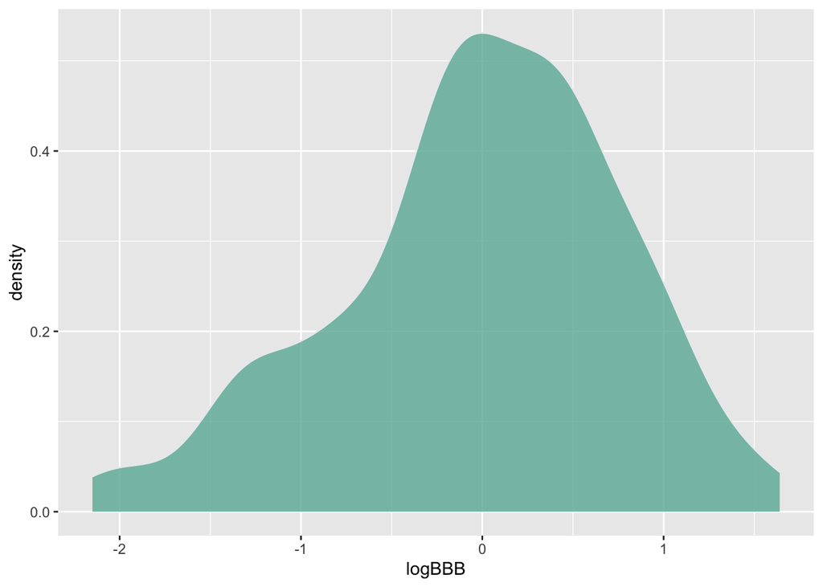

```r
table(is.na(mydata$logBBB))
```

```
##
## FALSE
##   208
```

Elle n’a aucune valeur nulle.

# 2 Famille de méthodes: Random Forest

## 2.1 Description de la famille de méthodes

Dans notre approche de modèlisation et de prédiction, nous utilisons comme précisé précédemmeent le package caret. Ce dernier propose une multitude de familles de méthodes et de sous-méthodes dans chacune de ces familles de méthodes.

# 3 Mise en oeuvre sous R

```r
set.seed(007)
trainIndex <- createDataPartition(y=mydata$logBBB, times=1, p=0.8, list=F)
# Train
Train_set <- mydata[trainIndex,]
Test_set <- mydata[-trainIndex,]
```

```r
library(randomForest)
library(Rborist)
library(RRF)
set.seed(007)
fit_Control_rcv <- trainControl(method = "repeatedcv",number=5)

speed_rf <- system.time(
mod_rf <- train(
             logBBB ~.,
             Train_set,
             method="rf",
             trControl = fit_Control_rcv,
             importance=T,
             preProcess = c("center","scale")
          )
)

speed_Rborist <- system.time(
mod_Rborist <- train(
             logBBB ~.,
             Train_set,
             method="Rborist",
             trControl = fit_Control_rcv,
             importance=T,
             preProcess = c("center","scale")
          )
)

speed_RRFglobal <- system.time(
mod_RRFglobal<- train(
             logBBB ~.,
             Train_set,
             method="RRFglobal",
             trControl = fit_Control_rcv,
             importance=T,
             preProcess = c("center","scale")
          )
)
```

```r
max(mod_rf$results$RMSE)
```

```
## [1] 0.5249069
```

```r
max(mod_Rborist$results$RMSE)
```

```
## [1] 0.5340995
```

```r
max(mod_RRFglobal$results$RMSE)
```

```
## [1] 0.616283
```

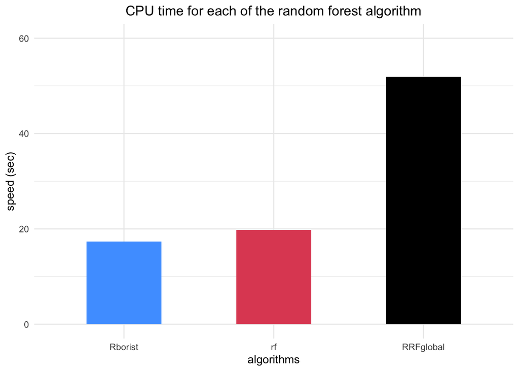

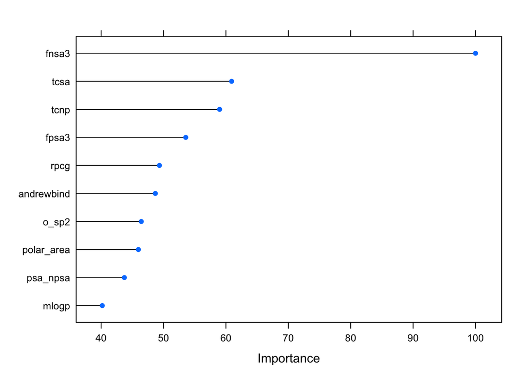

```r
plot(varImp(mod_rf),10)
```

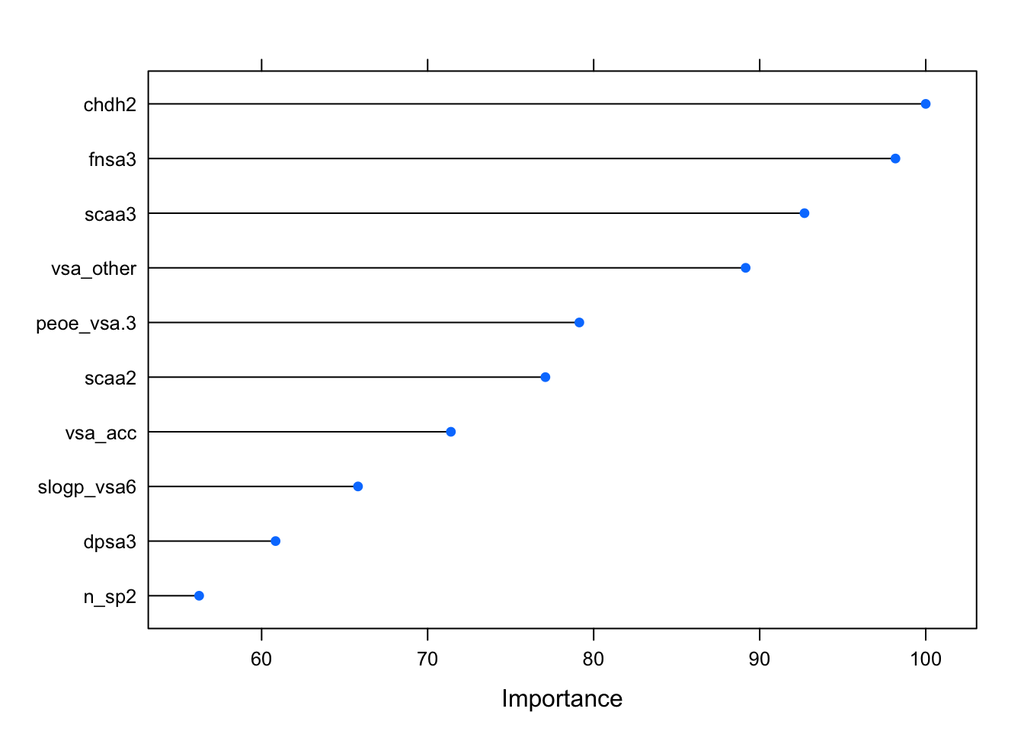

```r
plot(varImp(mod_Rborist), 10)
```

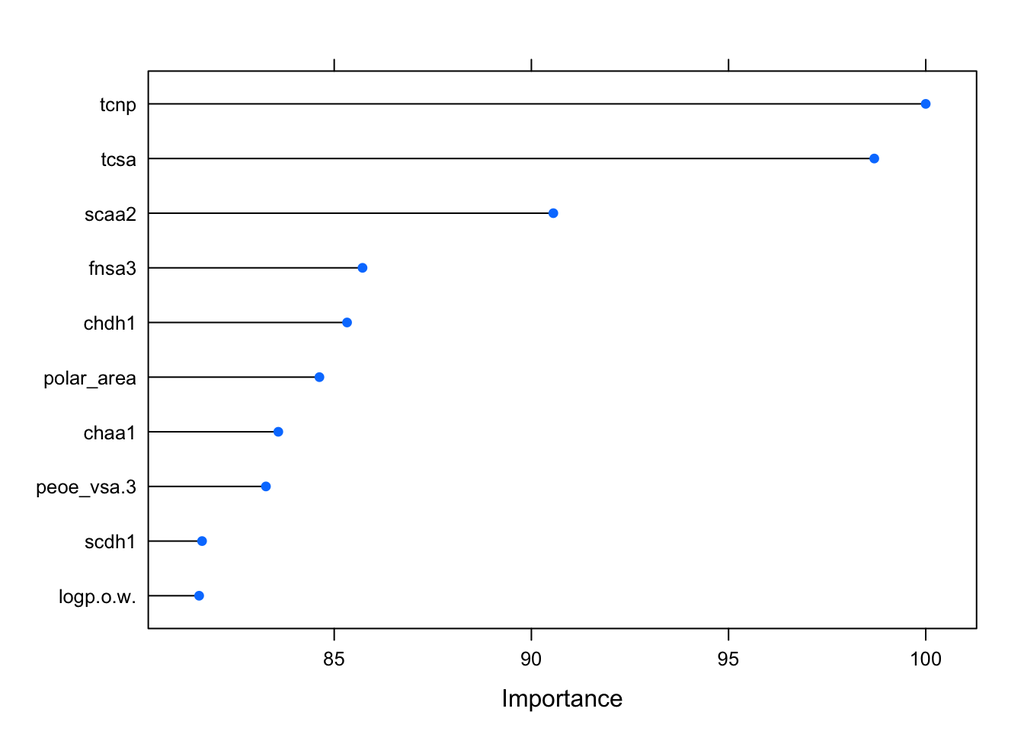

```r
plot(varImp(mod_RRFglobal), 10)
```

Afin de mieux comparer nos modèles, nous étudions plus largement les critères de performance fournis par l’entrainement sur le Train_set. Caret fournit en effet une fonction caret::resamples qui permet de collecter et d’analyser les résultats d’entrainement de modèles. La visualisation peut par la suite se faire facilement avec un dotplot aussi disponible dans le package.

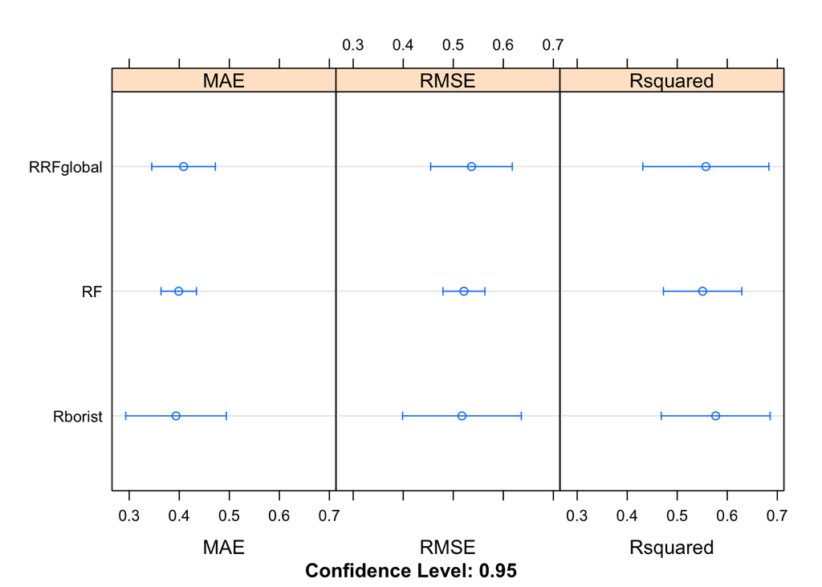

Nous constatons avec les trois critères présentés ci-dessus (le Mean Absolute Error - le Root Mean Square Error et le R^2) que les trois méthodes ont des performances quasi indentiques. Ces trois critères sont les plus utilisées dans les problématiques de regression.

Au delà de ces critères fournis directement par caret::train(), il est nécessaire d’étudier la performance de nos modèles sur des données autres que celles avec lesquelles elles ont été entrainées. Ce qui est un écueil à éviter dans une démarche cohérente et rigoureuse de machine learning.

Afin de réaliser l’étude de la performance nous utilons la fonction caret::predict() en lui fournissant le modèle sur lequel il va se baser et le Test_set (données de test).

```r
pred_rf <- predict(mod_rf, newdata = Test_set)
pred_Rborist <- predict(mod_Rborist, newdata = Test_set)
pred_RFglobal <- predict(mod_RRFglobal, newdata = Test_set)
```

En régression contrairement en classification, il n’est pas possible d’utiliser une matrice de confusion pour évaluer la performance de prédition de nos modèles de Random Forest.  
Nous nous proposons ici d’utiliser une techinique assez équivalente où l’on calcule la corrélation entre les valeurs prédites de logBBB et le logBBB dans le Test_set.

**Plus la corrélation entre ces valeurs est forte, plus notre modèle (et méthode) sera performante**.

Nous réprésentons par la suite graphiquement la performance de prédiction de chacune de nos méthodes.

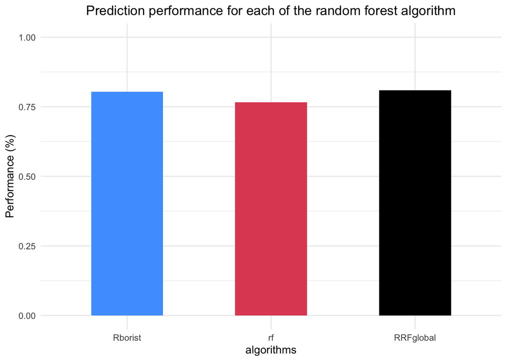

**Il ne semble pas y avoir de différence significative en termes de performance de prédiction entre nos trois méthodes.**

En guise de rappel, nous pouvons distinguer les trois méthodes que nous avons utilisé par les [hyperparamètres](https://fr.wikipedia.org/wiki/Hyperparam%C3%A8tre) tunés.

Pour rf caret ne tune que mtry, pour Rborist predFixed et minNode sont tunés et pour RRFglobal c’est mtry et coefReg qui sont optimisés.

```r
mod_rf$modelInfo$parameters[]
```

```
##   parameter   class                         label
## 1      mtry numeric #Randomly Selected Predictors
```

```r
mod_Rborist$modelInfo$parameters[]
```

```
##   parameter   class                         label
## 1 predFixed numeric #Randomly Selected Predictors
## 2   minNode numeric             Minimal Node Size
```

```r
mod_RRFglobal$modelInfo$parameters[]
```

```
##   parameter   class                         label
## 1      mtry numeric #Randomly Selected Predictors
## 2   coefReg numeric          Regularization Value
```

**Pour finir**:  
- Malgré qu’elles soient un poil boîtes noires, les méthodes de Random Forest ont connu une ascension très importante depuis leur initiation par Breiman et al. (2001) pour répondre d’abord aux insuffisances des arbres de décison puis à celles du [bagging](https://dataanalyticspost.com/Lexique/bagging/);  
- il en existe plusieurs déclinaisons disponibles dans caret. Nous en avons présenté ici 3 majeurs : rf, Rborist et RRFglobal;  
- au delà de leur efficacité démontré en classification comme en regression elles nous ont paru intéressantes dans le sens où la notion d’importance de variable est ici très pertinente et centrale;

# 5 Références

1. R Core Team (2020). R: A language and environment for statistical computing. R Foundation for Statistical Computing, Vienna, Austria. URL https://www.R-project.org/.
2. Max Kuhn (2020). caret: Classification and Regression Training. R package version 6.0-86. https://CRAN.R-project.org/package=caret
3. https://topepo.github.io/caret/